# Section 1: Data Loading & Cleaning

### Research Question 5: How does transaction amount relate to fraud occurrence?

Evaluating transaction values reveals whether anomalous activities scale proportionally with spending volume.

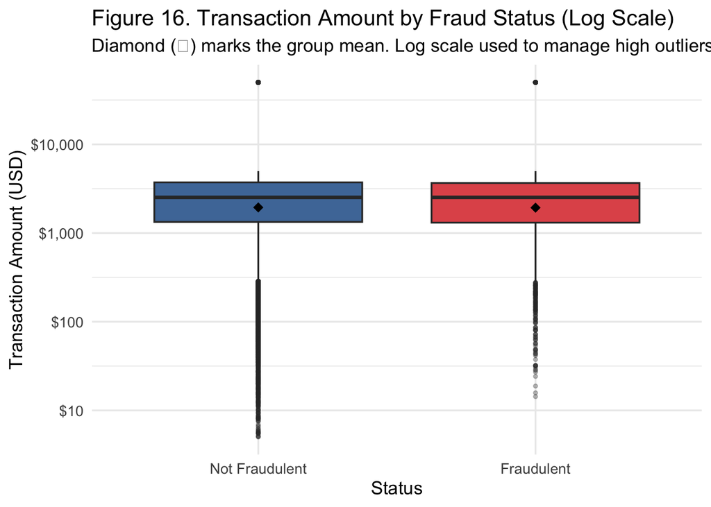

```r
# Plot 5A: Logged Amount Variant Comparison
p_rq5a <- ggplot(df, aes(x = factor(fraudulent), y = transaction_amount, fill = factor(fraudulent))) +
  geom_boxplot(outlier.alpha = 0.3, outlier.size = 1) +
  stat_summary(fun = mean, geom = "point", shape = 18, size = 3, color = "black") +
  scale_fill_manual(values = fraud_colors, labels = c("Not Fraudulent", "Fraudulent")) +
  scale_x_discrete(labels = c("Not Fraudulent", "Fraudulent")) +
  scale_y_log10(labels = dollar_format()) +
  labs(title = "Figure 16. Transaction Amount by Fraud Status (Log Scale)",
       subtitle = "Diamond (◆) marks the group mean. Log scale used to manage high outliers.",
       x = "Status", y = "Transaction Amount (USD)", fill = NULL) +
  theme_minimal(base_size = 13) +
  theme(legend.position = "none")

# Plot 5B: Logistic Regression Over Looped Log Ranges
p_rq5b <- ggplot(df, aes(x = transaction_amount, y = fraudulent)) +
  geom_jitter(height = 0.05, alpha = 0.03, size = 0.8, color = "#E15759") +
  geom_smooth(method = "glm", method.args = list(family = "binomial"),
              color = "#4E79A7", linewidth = 1.2, se = TRUE) +
  scale_x_log10(labels = dollar_format()) +
  annotation_logticks(sides = "b") +
  labs(title = "Figure 17. Probability of Fraud vs. Transaction Amount",
       subtitle = "The curve remains relatively flat even with extreme outliers.",
       x = "Transaction Amount (USD)", y = "Probability of Fraud") +
  theme_minimal(base_size = 13)

# Plot 5C: Cleaned Continuous Value Scale Density Comparison
p_rq5c <- ggplot(df, aes(x = transaction_amount, fill = factor(fraudulent))) +
  geom_density(alpha = 0.5) +
  scale_fill_manual(values = fraud_colors, labels = c("Not Fraudulent", "Fraudulent")) +
  scale_x_log10(labels = dollar_format()) +
  annotation_logticks(sides = "b") +
  labs(title = "Figure 18. Density of Transaction Amounts",
       subtitle = "Log scale reveals that Fraud and Legitimate patterns are nearly identical.",
       x = "Transaction Amount (USD)", y = "Density", fill = "Transaction Type") +
  theme_minimal(base_size = 13) +
  theme(legend.position = "top")

# Output structural charts
print(p_rq5a)
```

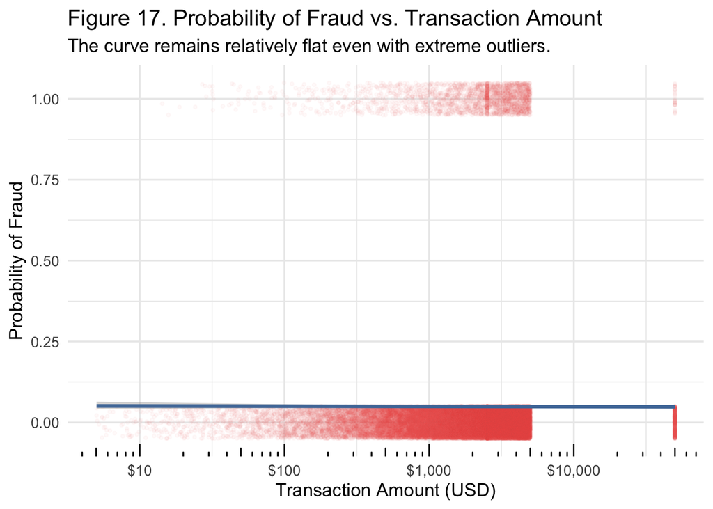

```r
print(p_rq5b)
```

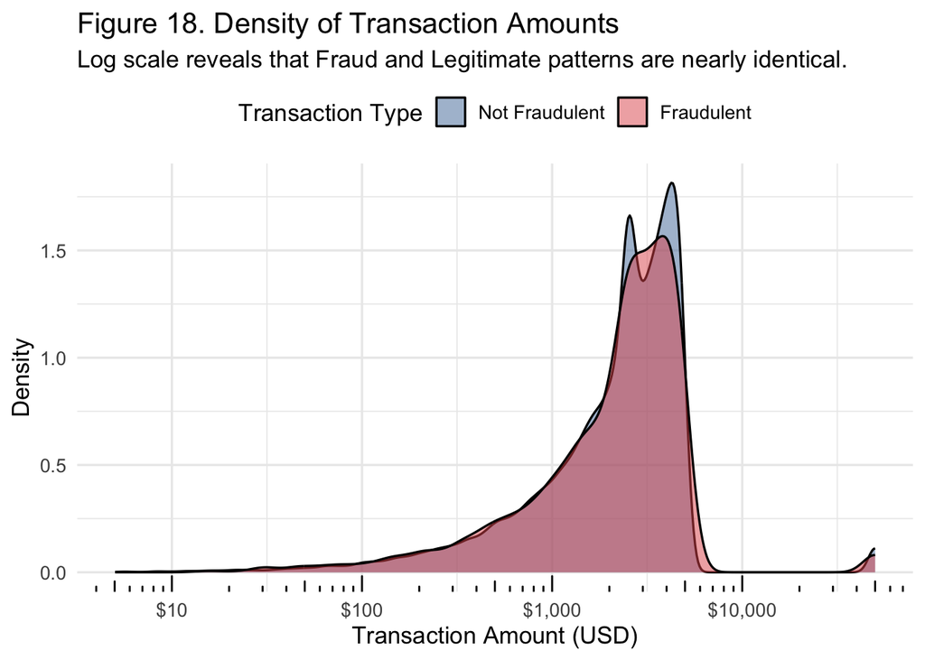

```r
print(p_rq5c)
```

# Section 4: Multivariate Logistic Regression Modeling

To control for confounding variables and evaluate structural hazard dependencies simultaneously, we fit a multi-predictor generalized linear model. This model isolates individual effect sizes to determine true transactional risk drivers.

### Feature Attributes Tested:

- **Financial Attributes:** `transaction_amount` (continuous asset sizes)
- **Velocity Constraints:** `number_of_transactions_last_24h` (short-term transaction counts)
- **Account Integrity Indicators:** `account_age` and historical flags (`previous_fraudulent_transactions`)
- **Contextual Profiles:** User configurations (`device_used`) and timing categories (`time_of_day`)

```r
# 1. Fit the complete multi-predictor structural model
model_full <- glm(fraudulent ~
                    transaction_amount +
                    number_of_transactions_last_24h +
                    account_age +
                    previous_fraudulent_transactions +
                    device_used +
                    time_of_day,
                  data = df, family = binomial)

# 2. Extract and inspect estimated statistical weights
summary(model_full)
```

```
##
## Call:
## glm(formula = fraudulent ~ transaction_amount + number_of_transactions_last_24h +
##     account_age + previous_fraudulent_transactions + device_used +
##     time_of_day, family = binomial, data = df)
##
## Coefficients:
##                                    Estimate Std. Error z value Pr(>|z|)
## (Intercept)                      -3.081e+00  8.119e-02 -37.950   <2e-16 ***
## transaction_amount                4.584e-06  3.811e-06   1.203   0.2291
## number_of_transactions_last_24h  -4.415e-03  5.094e-03  -0.867   0.3862
## account_age                       8.333e-04  5.957e-04   1.399   0.1619
## previous_fraudulent_transactions  4.358e-03  1.447e-02   0.301   0.7632
## device_usedMobile                 9.063e-02  5.208e-02   1.740   0.0818 .
## device_usedTablet                -1.272e-02  5.331e-02  -0.239   0.8115
## device_usedUnknown                1.894e-01  7.795e-02   2.430   0.0151 *
## time_of_dayMorning                1.661e-02  6.034e-02   0.275   0.7831
## time_of_dayAfternoon              4.903e-02  5.700e-02   0.860   0.3897
## time_of_dayEvening                8.839e-02  5.922e-02   1.493   0.1356
## ---
## Signif. codes:  0 '***' 0.001 '**' 0.01 '*' 0.05 '.' 0.1 ' ' 1
##
## (Dispersion parameter for binomial family taken to be 1)
##
##     Null deviance: 20012  on 50999  degrees of freedom
## Residual deviance: 19996  on 50989  degrees of freedom
## AIC: 20018
##
## Number of Fisher Scoring iterations: 5
```

```r
# 3. Output fit optimization summaries
cat("AIC Optimization Metric:", AIC(model_full), "\n")
```

```
## AIC Optimization Metric: 20017.85
```

```r
# 4. Clean up environmental tracking memory
rm(list = ls())
```